# Praktikum 6 MPDW

najwafach

2026-09-30

# Packages

```r
library(ggplot2)
library(tseries)
library(MASS)
library(forecast)
library(TSA)
library(lmtest)
```

# Data Harga Cabai Merah

## Import Data

```r
# Ganti nama file sesuai lokasi file di komputermu
cabai <- read.csv2("C:\\IPB\\TUGAASS!!!!\\SMT 5\\MPDW\\MPDW Cabai merah.csv")
cabai$Tanggal <- as.Date(cabai$Tanggal, format = "%d/%m/%Y")

# Ambil observasi ke-201 sampai ke-300
cabai <- cabai[202:301, ]
rownames(cabai) <- NULL

head(cabai)
```

```
##     Komoditas    Tanggal Harga
## 1 Cabai Merah 2021-10-15 34.70
## 2 Cabai Merah 2021-10-18 34.20
## 3 Cabai Merah 2021-10-19 34.30
## 4 Cabai Merah 2021-10-20 51.25
## 5 Cabai Merah 2021-10-21 34.40
## 6 Cabai Merah 2021-10-22 34.75
```

```r
tail(cabai)
```

```
##       Komoditas    Tanggal Harga
## 95  Cabai Merah 2022-02-24 47.45
## 96  Cabai Merah 2022-02-25 48.00
## 97  Cabai Merah 2022-03-01 50.10
## 98  Cabai Merah 2022-03-02 50.80
## 99  Cabai Merah 2022-03-04 51.85
## 100 Cabai Merah 2022-03-07 54.20
```

```r
str(cabai)
```

```
## 'data.frame':    100 obs. of  3 variables:
##  $ Komoditas: chr  "Cabai Merah" "Cabai Merah" "Cabai Merah" "Cabai Merah" ...
##  $ Tanggal  : Date, format: "2021-10-15" "2021-10-18" ...
##  $ Harga    : num  34.7 34.2 34.3 51.2 34.4 ...
```

```r
harga <- cabai$Harga
n <- length(harga)
n
```

```
## [1] 100
```

## Pembagian Data Latih dan Data Uji

Data dibagi menjadi data latih dan data uji dengan proporsi 80:20, yaitu 80 observasi pertama sebagai data latih dan 20 observasi terakhir sebagai data uji.

```r
n.train <- 80
n.test  <- n - n.train

train.raw <- harga[1:n.train]
test      <- harga[(n.train + 1):n]
tgl.test  <- cabai$Tanggal[(n.train + 1):n]

c(Data_Latih = n.train, Data_Uji = n.test)
```

```
## Data_Latih   Data_Uji
##         80         20
```

# Eksplorasi Data

## Plot Data Penuh

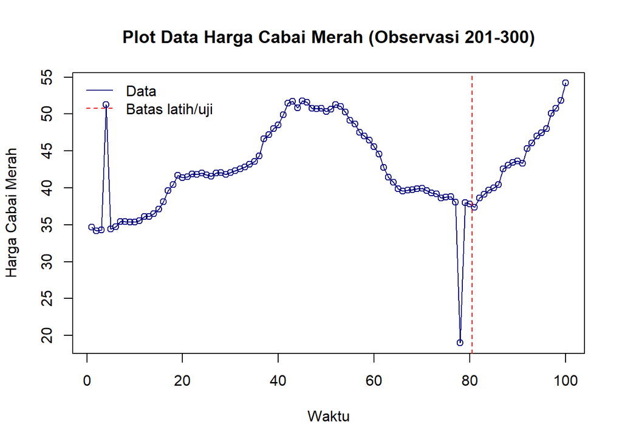

```r
ts.plot(ts(harga), col = "navyblue", type = "o", lwd = 1,
        xlab = "Waktu", ylab = "Harga Cabai Merah",
        main = "Plot Data Harga Cabai Merah (Observasi 201-300)")
abline(v = n.train + 0.5, col = "red", lty = 2)
legend("topleft", legend = c("Data", "Batas latih/uji"),
       col = c("navyblue", "red"), lty = c(1, 2), bty = "n")
```

Pada plot terlihat pergerakan harga naik turun dengan pola yang tidak berada di sekitar satu nilai tengah tertentu (terdapat tren naik dan turun). Selain itu, terdapat beberapa titik yang menyimpang jauh dari pola sekitarnya (pencilan).

## Pengecekan Pencilan pada Data Latih

Pencilan dapat mengganggu pendugaan model ARIMA sehingga dideteksi terlebih dahulu dengan `tsoutliers()`. Pengecekan hanya dilakukan pada **data latih** agar data uji tidak ikut mempengaruhi model.

```r
tangani_outlier <- TRUE

train.ts <- ts(train.raw)
out <- forecast::tsoutliers(train.ts)
out
```

```
## $index
## [1]  4 78
##
## $replacements
## [1] 34.350 38.025
```

```r
train.clean <- train.ts
if (tangani_outlier && length(out$index) > 0) {
  train.clean[out$index] <- out$replacements
}
```

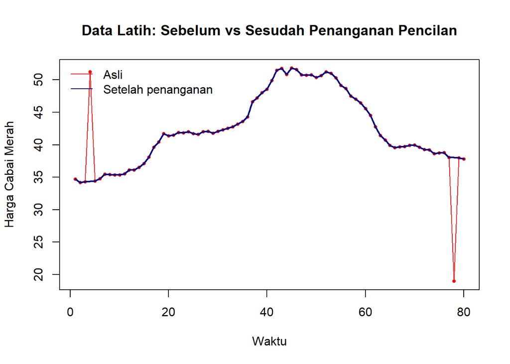

```r
plot(train.raw, type = "o", col = "red", pch = 16, cex = 0.6,
     xlab = "Waktu", ylab = "Harga Cabai Merah",
     main = "Data Latih: Sebelum vs Sesudah Penanganan Pencilan")
lines(as.numeric(train.clean), col = "navyblue", lwd = 2)
legend("topleft", legend = c("Asli", "Setelah penanganan"),
       col = c("red", "navyblue"), lty = 1, bty = "n")
```

Selanjutnya seluruh analisis memakai `train.ts` (data latih hasil penanganan pencilan).

```r
train.ts <- ts(as.numeric(train.clean))
test.ts  <- ts(test, start = n.train + 1)
```

## Plot Data Latih

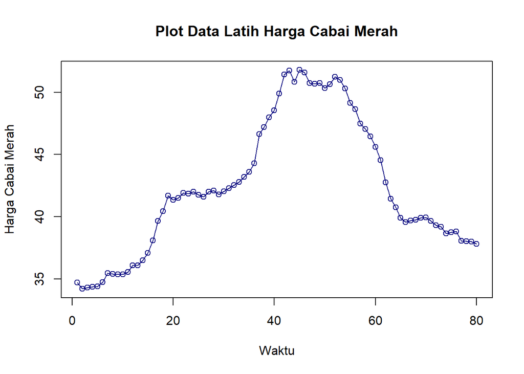

```r
plot.ts(train.ts, lty = 1, type = "o", col = "navyblue",
        xlab = "Waktu", ylab = "Harga Cabai Merah",
        main = "Plot Data Latih Harga Cabai Merah")
```

## Plot Data Uji

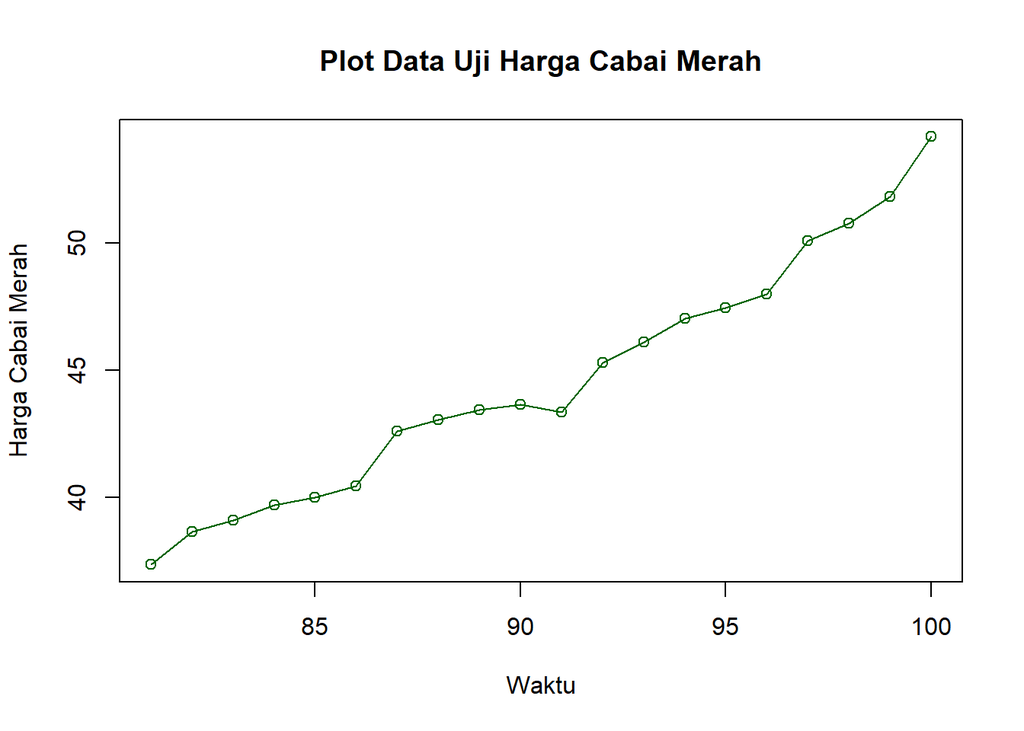

```r
plot.ts(test.ts, lty = 1, type = "o", col = "darkgreen",
        xlab = "Waktu", ylab = "Harga Cabai Merah",
        main = "Plot Data Uji Harga Cabai Merah")
```

# Uji Stasioneritas Data

## Plot ACF

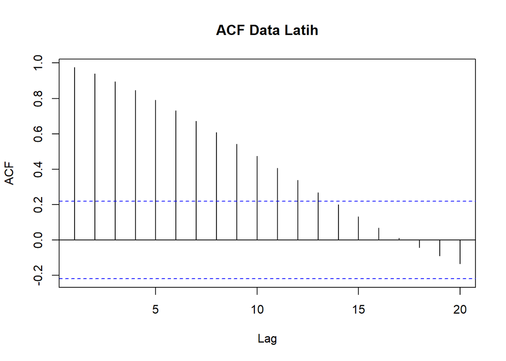

```r
acf(train.ts, main = "ACF Data Latih", lag.max = 20)
```

karena plot ACF menurun secara perlahan (*tails off slowly*), hal ini menjadi indikasi bahwa data tidak stasioner dalam rataan.

## Uji ADF

```r
adf.train <- tseries::adf.test(train.ts)
adf.train
```

```
##
##  Augmented Dickey-Fuller Test
##
## data:  train.ts
## Dickey-Fuller = -1.4653, Lag order = 4, p-value = 0.7945
## alternative hypothesis: stationary
```

$H_0$ : Data tidak stasioner dalam rataan

$H_1$ : Data stasioner dalam rataan

Berdasarkan uji ADF, didapat *p-value* sebesar 0.7945 sehingga pada taraf nyata 5% gagal tolak $H_0$, artinya data tidak stasioner dalam rataan.

## Plot Box-Cox

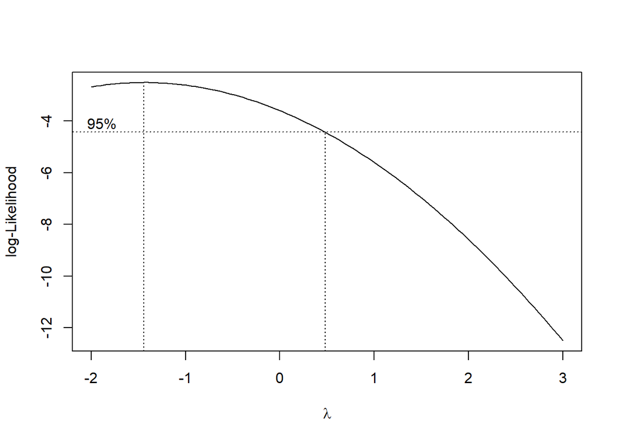

```r
index <- seq_along(train.ts)

bc <- boxcox(as.numeric(train.ts) ~ index, lambda = seq(-2, 3, by = 0.1))
```

```r
# Nilai lambda optimum
lambda_opt <- bc$x[which.max(bc$y)]
lambda_opt
```

```
## [1] -1.444444
```

```r
# Selang kepercayaan 95% untuk lambda
ci_lambda <- bc$x[bc$y > max(bc$y) - 0.5 * qchisq(0.95, df = 1)]
ci_lower <- min(ci_lambda)
ci_upper <- max(ci_lambda)

c(Batas_Bawah = ci_lower, Batas_Atas = ci_upper)
```

```
## Batas_Bawah  Batas_Atas
##  -2.0000000   0.4747475
```

Nilai $\lambda$ optimum sebesar -1.44 dengan selang kepercayaan 95% dari -2 sampai 0.47. Selang tersebut tidak memuat nilai satu sehingga data belum stasioner dalam ragam dan dapat dipertimbangkan transformasi.

# Penanganan Ketidakstasioneran Data

Banyaknya differencing yang dibutuhkan dicek dengan `ndiffs()` (berbasis uji ADF).

```r
d <- forecast::ndiffs(train.ts, test = "adf", alpha = 0.05)
d <- max(d, 1)   # materi memakai differencing minimal 1 kali
d
```

```
## [1] 1
```

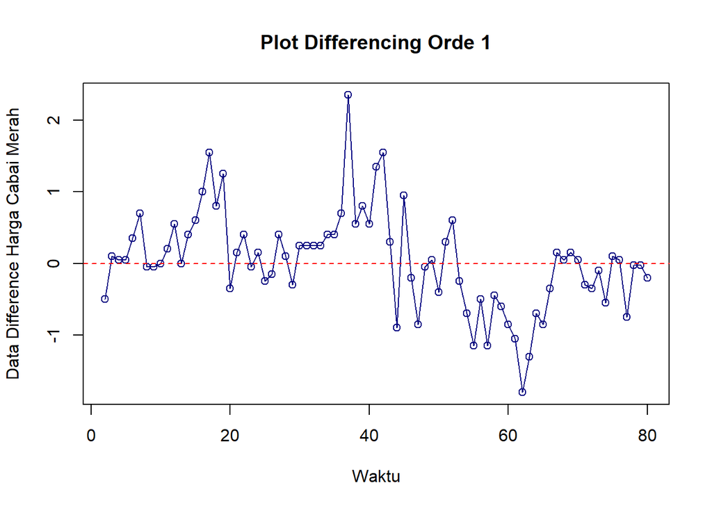

```r
train.diff <- diff(train.ts, differences = d)

plot.ts(train.diff, lty = 1, type = "o", col = "navyblue",
        xlab = "Waktu", ylab = "Data Difference Harga Cabai Merah",
        main = paste("Plot Differencing Orde", d))
abline(h = 0, col = "red", lty = 2)
```

Setelah differencing, data bergerak di sekitar nilai tengah tertentu (tidak ada tren yang jelas).

## Plot ACF Setelah Differencing

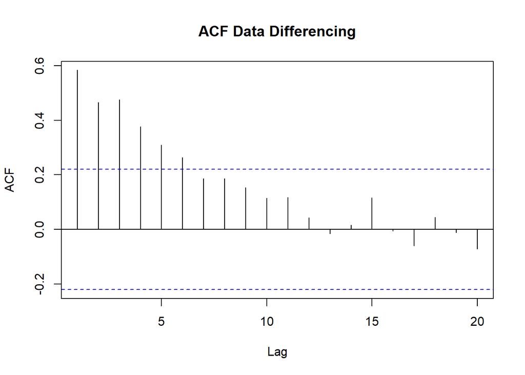

```r
acf(train.diff, main = "ACF Data Differencing", lag.max = 20)
```

## Uji ADF Setelah Differencing

```r
adf.diff <- tseries::adf.test(train.diff)
adf.diff
```

```
##
##  Augmented Dickey-Fuller Test
##
## data:  train.diff
## Dickey-Fuller = -2.5965, Lag order = 4, p-value = 0.3317
## alternative hypothesis: stationary
```

# Identifikasi Model

## Plot ACF

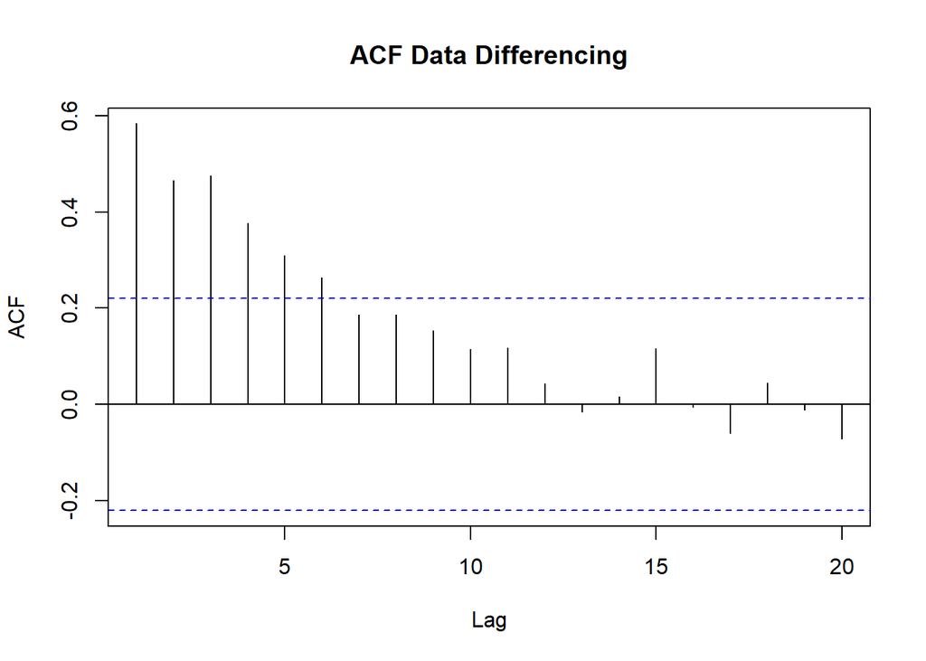

```r
acf(train.diff, main = "ACF Data Differencing", lag.max = 20)
```

Lag ACF yang signifikan (keluar dari garis batas) dan pola *cuts off* digunakan untuk menentukan orde MA(q).

## Plot PACF

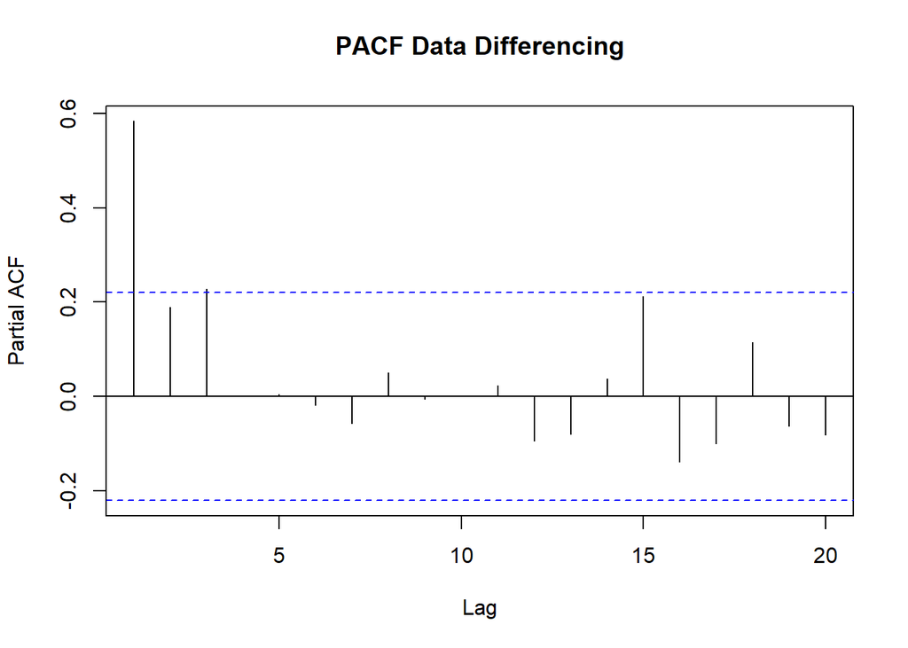

```r
pacf(train.diff, main = "PACF Data Differencing", lag.max = 20)
```

Lag PACF yang signifikan dan pola *cuts off* digunakan untuk menentukan orde AR(p).

## Plot EACF

```r
eacf(train.diff)
```

```
## AR/MA
##   0 1 2 3 4 5 6 7 8 9 10 11 12 13
## 0 x x x x x x o o o o o  o  o  o
## 1 x o o o o o o o o o o  o  o  o
## 2 x x o o o o o o o o o  o  o  o
## 3 o o o o o o o o o o o  o  o  o
## 4 o o o o o o o o o o o  o  o  o
## 5 o o o o o o o o o o o  o  o  o
## 6 x x o o o o o o o o o  o  o  o
## 7 x x o x o o o o o o o  o  o  o
```

Model tentatif dari EACF ditentukan dengan melihat ujung segitiga nol (`o`). Berdasarkan plot ACF, PACF, dan EACF di atas, ditentukan model-model tentatif pada bagian berikut.

# Pendugaan Parameter Model Tentatif

```r
kandidat <- list(
  c(1, d, 0),
  c(2, d, 0),
  c(3, d, 0)
)

nama_model <- function(o) paste0("ARIMA(", paste(o, collapse = ","), ")")

# Model ARIMA(p,d,q) langsung diduga pada data latih (bukan data hasil diff),
# sehingga hasil ramalan sudah berada pada skala harga asli
fit_arima <- function(y, o) {
  tryCatch(Arima(y, order = o, method = "ML"), error = function(e) NULL)
}

model_list <- lapply(kandidat, function(o) fit_arima(train.ts, o))
names(model_list) <- sapply(kandidat, nama_model)
```

Ringkasan dan uji signifikansi parameter setiap model:

```r
for (nm in names(model_list)) {
  cat("\n=====", nm, "=====\n")
  if (is.null(model_list[[nm]])) {
    cat("Model gagal diduga\n")
  } else {
    print(lmtest::coeftest(model_list[[nm]]))
  }
}
```

```
##
## ===== ARIMA(1,1,0) =====
##
## z test of coefficients:
##
##     Estimate Std. Error z value  Pr(>|z|)
## ar1 0.583223   0.090154  6.4692 9.853e-11 ***
## ---
## Signif. codes:  0 '***' 0.001 '**' 0.01 '*' 0.05 '.' 0.1 ' ' 1
##
##
## ===== ARIMA(2,1,0) =====
##
## z test of coefficients:
##
##     Estimate Std. Error z value  Pr(>|z|)
## ar1  0.47331    0.11014  4.2974 1.728e-05 ***
## ar2  0.18362    0.10988  1.6712   0.09468 .
## ---
## Signif. codes:  0 '***' 0.001 '**' 0.01 '*' 0.05 '.' 0.1 ' ' 1
##
##
## ===== ARIMA(3,1,0) =====
##
## z test of coefficients:
##
##     Estimate Std. Error z value  Pr(>|z|)
## ar1 0.430686   0.109321  3.9396 8.161e-05 ***
## ar2 0.075657   0.119330  0.6340   0.52607
## ar3 0.222282   0.108144  2.0554   0.03984 *
## ---
## Signif. codes:  0 '***' 0.001 '**' 0.01 '*' 0.05 '.' 0.1 ' ' 1
```

```r
semua_signifikan <- function(m) {
  p <- tryCatch(lmtest::coeftest(m)[, 4], error = function(e) NA)
  isTRUE(all(p < 0.05))
}

ok <- !sapply(model_list, is.null)
model_ok <- model_list[ok]

hasil_model <- data.frame(
  Model  = names(model_ok),
  AIC    = sapply(model_ok, AIC),
  BIC    = sapply(model_ok, BIC),
  Semua_Parameter_Signifikan = sapply(model_ok, semua_signifikan),
  row.names = NULL
)
hasil_model[order(hasil_model$AIC), ]
```

```
##          Model      AIC      BIC Semua_Parameter_Signifikan
## 3 ARIMA(3,1,0) 131.3346 140.8124                      FALSE
## 2 ARIMA(2,1,0) 133.4310 140.5394                      FALSE
## 1 ARIMA(1,1,0) 134.1694 138.9083                       TRUE
```

## Pemilihan Model Terbaik

Model terbaik dipilih berdasarkan **AIC/ BIC terkecil** dengan syarat seluruh parameter signifikan. Jika tidak ada model yang seluruh parameternya signifikan, dipilih model dengan AIC terkecil.

```r
pool <- hasil_model[hasil_model$Semua_Parameter_Signifikan, ]
if (nrow(pool) == 0) pool <- hasil_model

nama_terbaik  <- pool$Model[which.min(pool$AIC)]
model.terbaik <- model_ok[[nama_terbaik]]
order.terbaik <- arimaorder(model.terbaik)   # p, d, q

nama_terbaik
```

```
## [1] "ARIMA(1,1,0)"
```

```r
summary(model.terbaik)
```

```
## Series: y
## ARIMA(1,1,0)
##
## Coefficients:
##          ar1
##       0.5832
## s.e.  0.0902
##
## sigma^2 = 0.3065:  log likelihood = -65.08
## AIC=134.17   AICc=134.33   BIC=138.91
##
## Training set error measures:
##                      ME      RMSE       MAE        MPE      MAPE      MASE
## Training set 0.01629856 0.5466334 0.4165471 0.04870162 0.9547429 0.8373339
##                    ACF1
## Training set -0.1077457
```

```r
lmtest::coeftest(model.terbaik)
```

```
##
## z test of coefficients:
##
##     Estimate Std. Error z value  Pr(>|z|)
## ar1 0.583223   0.090154  6.4692 9.853e-11 ***
## ---
## Signif. codes:  0 '***' 0.001 '**' 0.01 '*' 0.05 '.' 0.1 ' ' 1
```

Model terbaik yang terpilih adalah **ARIMA(1,1,0)**.

# Analisis Sisaan

Sisaan model ARIMA harus memenuhi asumsi normalitas, kebebasan sisaan, kehomogenan ragam, dan nilai tengah sama dengan nol. Sisaan observasi pertama dibuang karena pada model dengan differencing nilainya hanya akibat inisialisasi model.

```r
sisaan <- as.numeric(residuals(model.terbaik))
sisaan <- sisaan[-1]
```

## Eksplorasi Sisaan

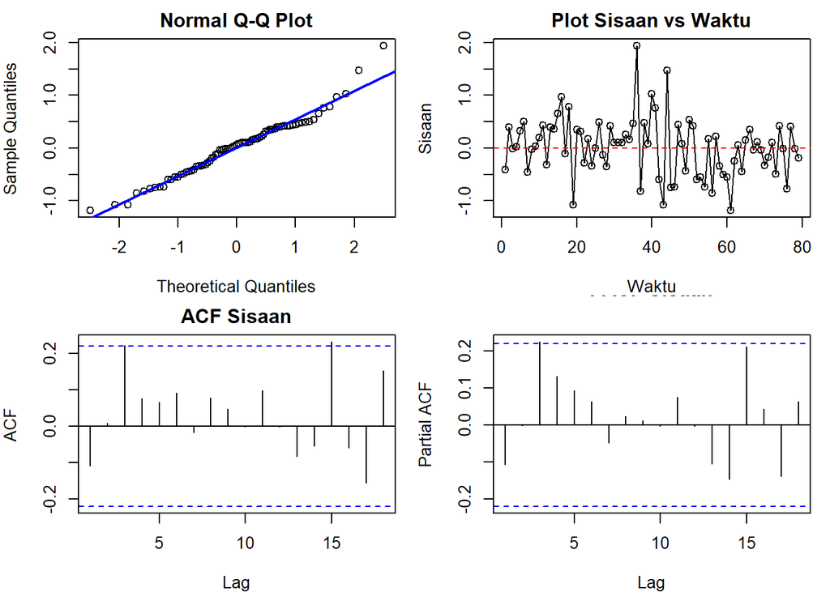

```r
par(mfrow = c(2, 2), mar = c(4, 4, 2, 1))

qqnorm(sisaan, main = "Normal Q-Q Plot")
qqline(sisaan, col = "blue", lwd = 2)

plot(sisaan, type = "o", main = "Plot Sisaan vs Waktu",
     xlab = "Waktu", ylab = "Sisaan")
abline(h = 0, col = "red", lty = 2)

acf(sisaan, main = "ACF Sisaan")
pacf(sisaan, main = "PACF Sisaan")
```

```r
par(mfrow = c(1, 1))
```

Plot kuantil-kuantil normal digunakan untuk melihat kenormalan (titik mengikuti garis), plot sisaan terhadap waktu untuk melihat kehomogenan ragam (lebar pita sisaan), serta plot ACF dan PACF sisaan untuk melihat kebebasan sisaan (tidak ada lag yang signifikan).

## Uji Formal

### Kenormalan Sisaan

```r
uji.norm <- ks.test(sisaan, "pnorm", mean = mean(sisaan), sd = sd(sisaan))
uji.norm
```

```
##
##  Asymptotic one-sample Kolmogorov-Smirnov test
##
## data:  sisaan
## D = 0.091678, p-value = 0.5202
## alternative hypothesis: two-sided
```

$H_0$ : Sisaan menyebar normal

$H_1$ : Sisaan tidak menyebar normal

*P-value* uji Kolmogorov-Smirnov sebesar 0.5202 sehingga gagal tolak $H_0$, sisaan menyebar normal pada taraf nyata 5%.

### Kebebasan Sisaan

```r
lag.uji <- 10
fitdf   <- order.terbaik[1] + order.terbaik[3]   # p + q

uji.bebas <- Box.test(sisaan, lag = lag.uji, type = "Ljung-Box", fitdf = fitdf)
uji.bebas
```

```
##
##  Box-Ljung test
##
## data:  sisaan
## X-squared = 7.4832, df.p = 9, p-value = 0.5869
```

$H_0$ : Sisaan saling bebas

$H_1$ : Sisaan tidak saling bebas

*P-value* uji Ljung-Box sebesar 0.5869 sehingga gagal tolak $H_0$, sisaan saling bebas pada taraf nyata 5%.

### Kehomogenan Ragam Sisaan

```r
uji.homo <- Box.test(sisaan^2, lag = lag.uji, type = "Ljung-Box")
uji.homo
```

```
##
##  Box-Ljung test
##
## data:  sisaan^2
## X-squared = 11.982, df = 10, p-value = 0.2863
```

$H_0$ : Ragam sisaan homogen

$H_1$ : Ragam sisaan tidak homogen

*P-value* uji Ljung-Box terhadap sisaan kuadrat sebesar 0.2863 sehingga gagal tolak $H_0$, ragam sisaan homogen pada taraf nyata 5%.

### Nilai Tengah Sisaan

```r
uji.t <- t.test(sisaan, mu = 0, conf.level = 0.95)
uji.t
```

```
##
##  One Sample t-test
##
## data:  sisaan
## t = 0.25806, df = 78, p-value = 0.797
## alternative hypothesis: true mean is not equal to 0
## 95 percent confidence interval:
##  -0.1078774  0.1400086
## sample estimates:
##  mean of x
## 0.01606563
```

$H_0$ : Nilai tengah sisaan sama dengan 0

$H_1$ : Nilai tengah sisaan tidak sama dengan 0

*P-value* uji-t sebesar 0.797 sehingga gagal tolak $H_0$, nilai tengah sisaan sama dengan nol pada taraf nyata 5%.

# Overfitting

*Overfitting* dilakukan dengan menaikkan orde AR(p) dan MA(q) dari model terbaik, yaitu **ARIMA(1,1,0)**, untuk melihat apakah ada model yang lebih baik.

```r
p0 <- order.terbaik[1]; d0 <- order.terbaik[2]; q0 <- order.terbaik[3]

ord.over1 <- c(p0 + 1, d0, q0)
ord.over2 <- c(p0, d0, q0 + 1)

model.over1 <- fit_arima(train.ts, ord.over1)
model.over2 <- fit_arima(train.ts, ord.over2)

cat("=====", nama_model(ord.over1), "=====\n")
```

```
## ===== ARIMA(2,1,0) =====
```

```r
if (!is.null(model.over1)) print(lmtest::coeftest(model.over1))
```

```
##
## z test of coefficients:
##
##     Estimate Std. Error z value  Pr(>|z|)
## ar1  0.47331    0.11014  4.2974 1.728e-05 ***
## ar2  0.18362    0.10988  1.6712   0.09468 .
## ---
## Signif. codes:  0 '***' 0.001 '**' 0.01 '*' 0.05 '.' 0.1 ' ' 1
```

```r
cat("\n=====", nama_model(ord.over2), "=====\n")
```

```
##
## ===== ARIMA(1,1,1) =====
```

```r
if (!is.null(model.over2)) print(lmtest::coeftest(model.over2))
```

```
##
## z test of coefficients:
##
##      Estimate Std. Error z value  Pr(>|z|)
## ar1  0.852445   0.084327 10.1089 < 2.2e-16 ***
## ma1 -0.451852   0.149228 -3.0279  0.002462 **
## ---
## Signif. codes:  0 '***' 0.001 '**' 0.01 '*' 0.05 '.' 0.1 ' ' 1
```

```r
kumpulan <- list(model.terbaik, model.over1, model.over2)
nama_k   <- c(nama_terbaik, nama_model(ord.over1), nama_model(ord.over2))
ada      <- !sapply(kumpulan, is.null)

overfitting <- data.frame(
  Model = nama_k[ada],
  AIC   = sapply(kumpulan[ada], AIC),
  BIC   = sapply(kumpulan[ada], BIC),
  Semua_Parameter_Signifikan = sapply(kumpulan[ada], semua_signifikan),
  row.names = NULL
)
overfitting
```

```
##          Model      AIC      BIC Semua_Parameter_Signifikan
## 1 ARIMA(1,1,0) 134.1694 138.9083                       TRUE
## 2 ARIMA(2,1,0) 133.4310 140.5394                      FALSE
## 3 ARIMA(1,1,1) 131.0198 138.1281                       TRUE
```

```r
# Model final: model overfitting dipakai hanya jika AIC lebih kecil
# dan seluruh parameternya signifikan
model.final <- model.terbaik
nama_final  <- nama_terbaik

for (i in seq_len(nrow(overfitting))[-1]) {
  if (overfitting$AIC[i] < AIC(model.final) &&
      overfitting$Semua_Parameter_Signifikan[i]) {
    nama_final  <- overfitting$Model[i]
    model.final <- kumpulan[ada][[i]]
  }
}
nama_final
```

```
## [1] "ARIMA(1,1,1)"
```

Model yang digunakan untuk peramalan adalah **ARIMA(1,1,1)**.

# Peramalan

Peramalan dilakukan menggunakan fungsi `forecast()` sebanyak 20 periode ke depan, sesuai banyaknya data uji. Karena model ARIMA diduga langsung pada data latih (dengan d = 1), hasil ramalan sudah berada pada skala harga asli sehingga tidak perlu *inverse differencing*.

```r
ramalan <- forecast::forecast(model.final, h = n.test)
ramalan
```

```
##     Point Forecast    Lo 80    Hi 80    Lo 95    Hi 95
##  81       37.68483 36.99427 38.37539 36.62871 38.74095
##  82       37.58665 36.39823 38.77507 35.76912 39.40418
##  83       37.50296 35.81194 39.19399 34.91676 40.08917
##  84       37.43162 35.23370 39.62955 34.07019 40.79306
##  85       37.37081 34.66660 40.07501 33.23509 41.50653
##  86       37.31897 34.11332 40.52461 32.41636 42.22157
##  87       37.27478 33.57561 40.97394 31.61740 42.93215
##  88       37.23710 33.05445 41.41976 30.84029 43.63392
##  89       37.20499 32.55022 41.85976 30.08614 44.32384
##  90       37.17762 32.06292 42.29232 29.35536 44.99988
##  91       37.15428 31.59222 42.71635 28.64784 45.66073
##  92       37.13439 31.13763 43.13115 27.96314 46.30564
##  93       37.11743 30.69855 43.53632 27.30059 46.93427
##  94       37.10298 30.27427 43.93169 26.65937 47.54659
##  95       37.09066 29.86408 44.31723 26.03856 48.14275
##  96       37.08015 29.46724 44.69307 25.43721 48.72310
##  97       37.07120 29.08303 45.05937 24.85435 49.28805
##  98       37.06357 28.71073 45.41640 24.28901 49.83813
##  99       37.05706 28.34967 45.76445 23.74025 50.37387
## 100       37.05152 27.99919 46.10384 23.20717 50.89586
```

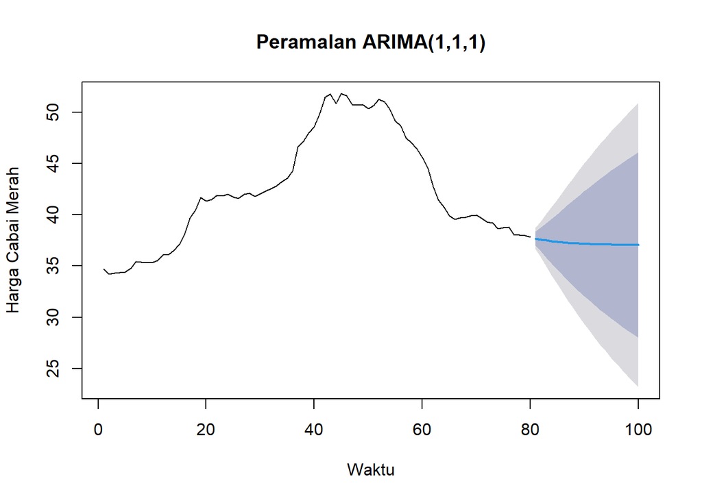

```r
plot(ramalan, main = paste("Peramalan", nama_final),
     xlab = "Waktu", ylab = "Harga Cabai Merah")
```

## Perbandingan Data Aktual dan Hasil Ramalan

```r
hasil.ramalan <- as.numeric(ramalan$mean)

perbandingan <- data.frame(
  Tanggal = tgl.test,
  Aktual  = test,
  Forecast = round(hasil.ramalan, 3),
  Selisih  = round(test - hasil.ramalan, 3)
)
perbandingan
```

```
##       Tanggal Aktual Forecast Selisih
## 1  2022-02-04  37.35   37.685  -0.335
## 2  2022-02-07  38.65   37.587   1.063
## 3  2022-02-08  39.10   37.503   1.597
## 4  2022-02-09  39.70   37.432   2.268
## 5  2022-02-10  40.00   37.371   2.629
## 6  2022-02-11  40.45   37.319   3.131
## 7  2022-02-14  42.60   37.275   5.325
## 8  2022-02-15  43.05   37.237   5.813
## 9  2022-02-16  43.45   37.205   6.245
## 10 2022-02-17  43.65   37.178   6.472
## 11 2022-02-18  43.35   37.154   6.196
## 12 2022-02-21  45.30   37.134   8.166
## 13 2022-02-22  46.10   37.117   8.983
## 14 2022-02-23  47.05   37.103   9.947
## 15 2022-02-24  47.45   37.091  10.359
## 16 2022-02-25  48.00   37.080  10.920
## 17 2022-03-01  50.10   37.071  13.029
## 18 2022-03-02  50.80   37.064  13.736
## 19 2022-03-04  51.85   37.057  14.793
## 20 2022-03-07  54.20   37.052  17.148
```

## Akurasi Peramalan

```r
akurasi_test <- accuracy(hasil.ramalan, test)
akurasi_test
```

```
##                ME     RMSE      MAE      MPE     MAPE
## Test set 7.374321 8.807065 7.407804 15.59559 15.68524
```

Nilai MAPE sebesar 15.69% menunjukkan rata-rata persentase kesalahan ramalan terhadap data uji. Semakin kecil nilai RMSE, MAE, dan MAPE maka semakin baik ketepatan ramalan.

## Plot Aktual vs Ramalan

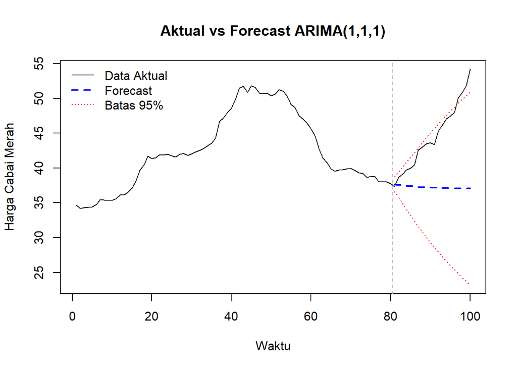

```r
y.full <- c(as.numeric(train.ts), test)
idx.uji <- (n.train + 1):n

ylim <- range(y.full, ramalan$lower, ramalan$upper)

ts.plot(ts(y.full), col = "black", lty = 1, ylim = ylim,
        xlab = "Waktu", ylab = "Harga Cabai Merah",
        main = paste("Aktual vs Forecast", nama_final))
lines(idx.uji, hasil.ramalan, col = "blue", lty = 2, lwd = 2)
lines(idx.uji, ramalan$lower[, 2], col = "red", lty = 3)
lines(idx.uji, ramalan$upper[, 2], col = "red", lty = 3)
abline(v = n.train + 0.5, col = "grey", lty = 2)
legend("topleft",
       legend = c("Data Aktual", "Forecast", "Batas 95%"),
       col = c("black", "blue", "red"),
       lty = c(1, 2, 3), lwd = c(1, 2, 1), bty = "n")
```

# Kesimpulan